# Lab06: Logistic Regression

Author

Shiu-Ting Ling

**Handout date:**Monday, April 15, 2026

**FIRM DUE DATA:** Friday, April 24, 2026 FIRM SUBMISSION DATE

**Submission Format:** Submit your lab as R Markdown document `Lab06YourName.rmd` to eLearning’s *SumitLab06* link in the **Labs** folder. Put your name behind the author’s keyword into the header of the YAML header of the Markdown file. Make sure that your R Markdown document renders properly into an `html` document. Otherwise, we will *not* be able to grade your lab!

*This lab counts 8 points towards your final grade.*

# Part 1: Logistic Regression Model for a Binary Outcome [6 points]

You will be working with the dataset `Mroz` which is in the `car` library. The data can be read in with

```r
library(carData)
data(Mroz)
attach(Mroz)
```

The dependent variable in the data set is the wife’s labor-force participation `lfp`.

Variable Description:

| Name | Description |
| --- | --- |
| lfp | wife labor-force participation; a factor with levels: ‘no’; ‘yes’ |
| k5 | number of children 5 years old or younger |
| k618 | number of children 6 to 18 years old |
| age | wife’s age in years |
| wc | wife’s college attendance; a factor with levels: ‘no’; ‘yes’ |
| hc | husband’s college attendance; a factor with levels: ‘no’; ‘yes’ |
| lwg | log expected wage rate; for women in the labor force, the actual wage rate; for women not in the labor force, an imputed value based on the regression of ‘lwg’ on the other variables. |
| inc | family income exclusive of wife’s income |

More information on this data set can be found in the online help of the `car` library.

## Task 1: Direction of influence [1 point]

Specify with *common sense arguments* into which directions all independent variables may influence the wife’s propensity to participate in the labor force. Use a table to with the headings [a] variable name, [b] argument and [c] *null* and *alternative* hypotheses for your answer.

*Show your answer here.*

### 1 answer

The dependent variable `lfp` indicates whether a wife participates in the labor force. Using common sense, we can reason about the expected direction of each predictor’s influence on the probability of participation:

| Variable | Common Sense Argument | H₀ | H₁ |
| --- | --- | --- | --- |
| `k5` | More young children (≤5 yrs) increase childcare demands at home, reducing the wife’s likelihood of working outside. | β = 0 | β < 0 |
| `k618` | Older children (6–18 yrs) require less intensive care, but may still create some household burden; the negative effect is expected to be weaker than `k5`. | β = 0 | β < 0 |
| `age` | Older wives are closer to retirement age and may belong to cohorts with more traditional gender-role expectations, reducing labor force participation. | β = 0 | β < 0 |
| `wc` | A wife with college education has higher earning potential and stronger career motivation, increasing her likelihood of participating in the labor force. | β = 0 | β > 0 |
| `hc` | A husband with college education likely earns a higher income, reducing the financial pressure on the wife to work. | β = 0 | β < 0 |
| `lwg` | A higher expected (or actual) wage rate raises the opportunity cost of not working, making labor force participation more attractive. | β = 0 | β > 0 |
| `inc` | Higher family income (excluding wife’s earnings) reduces the household’s financial need for the wife to work. | β = 0 | β < 0 |

## Task 2: Model discussion [3 points]

[a] Build a logistic regression model for the probability of `lfp` with these independent variables and give the 95% confidence intervals around the estimated logistic regression parameters.

*Show your answer here.*

### 2-a answer

Build the logistic regression model based on

$$\log\left(\frac{\Pr(\text{lfp}_i = \text{yes})}{1 - \Pr(\text{lfp}_i = \text{yes})}\right) =
\beta_0 + \beta_1\, k5_i + \beta_2\, k618_i + \beta_3\, age_i
+ \beta_4\, wc^{yes}_i + \beta_5\, hc^{yes}_i + \beta_6\, lwg_i + \beta_7\, inc_i$$

```r
## Full logistic regression model for wife's labor force participation
## Adapted from SchoolClosing.r lines 60-65 (GLM.02 full model pattern)
GLM.lfp <- glm(lfp ~ k5 + k618 + age + wc + hc + lwg + inc,
               family=binomial(logit), data=Mroz,
               control=list(epsilon=1e-15, maxit=50, trace=TRUE))
```

```
Deviance = 905.4065 Iterations - 1
Deviance = 905.2659 Iterations - 2
Deviance = 905.2659 Iterations - 3
Deviance = 905.2659 Iterations - 4
```

```r
summary(GLM.lfp, correlation=TRUE)
```

```
Call:
glm(formula = lfp ~ k5 + k618 + age + wc + hc + lwg + inc, family = binomial(logit),
    data = Mroz, control = list(epsilon = 1e-15, maxit = 50,
        trace = TRUE))

Coefficients:
             Estimate Std. Error z value Pr(>|z|)
(Intercept)  3.182140   0.644375   4.938 7.88e-07 ***
k5          -1.462913   0.197001  -7.426 1.12e-13 ***
k618        -0.064571   0.068001  -0.950 0.342337
age         -0.062871   0.012783  -4.918 8.73e-07 ***
wcyes        0.807274   0.229980   3.510 0.000448 ***
hcyes        0.111734   0.206040   0.542 0.587618
lwg          0.604693   0.150818   4.009 6.09e-05 ***
inc         -0.034446   0.008208  -4.196 2.71e-05 ***
---
Signif. codes:  0 '***' 0.001 '**' 0.01 '*' 0.05 '.' 0.1 ' ' 1

(Dispersion parameter for binomial family taken to be 1)

    Null deviance: 1029.75  on 752  degrees of freedom
Residual deviance:  905.27  on 745  degrees of freedom
AIC: 921.27

Number of Fisher Scoring iterations: 4

Correlation of Coefficients:
      (Intercept) k5    k618  age   wcyes hcyes lwg
k5    -0.50
k618  -0.53        0.15
age   -0.93        0.49  0.43
wcyes  0.09       -0.10  0.05 -0.04
hcyes -0.09       -0.07 -0.01  0.11 -0.44
lwg   -0.19       -0.03  0.07 -0.03 -0.19  0.00
inc   -0.12        0.08 -0.06 -0.08 -0.13 -0.29 -0.09
```

```r
logLik(GLM.lfp)
```

```
'log Lik.' -452.633 (df=8)
```

```r
## 95% Confidence intervals for logistic regression coefficients
## Adapted from SchoolClosing.r line 65
cbind(Coefficients=coef(GLM.lfp), confint(GLM.lfp, level=0.95))
```

[output not shown]

[output cut: 215 more lines]

[output not shown]

```
            Coefficients       2.5 %      97.5 %
(Intercept)   3.18214046  1.93697359  4.46630794
k5           -1.46291304 -1.86089654 -1.08747196
k618         -0.06457068 -0.19839650  0.06867096
age          -0.06287055 -0.08830325 -0.03813509
wcyes         0.80727378  0.36099360  1.26377557
hcyes         0.11173357 -0.29200419  0.51679061
lwg           0.60469312  0.31402218  0.90697688
inc          -0.03444643 -0.05099767 -0.01877093
```

[b] *Discuss* your model output in the light of your stated hypotheses from task 1.

*Show your answer here.*

### 2-b answer

$$\log\left(\frac{\Pr(\text{lfp}_i = \text{yes})}{1 - \Pr(\text{lfp}_i = \text{yes})}\right) =
3.182 - 1.463\, k5_i - 0.065\, k618_i - 0.063\, age_i
+ 0.807\, wc^{yes}_i + 0.112\, hc^{yes}_i + 0.605\, lwg_i - 0.034\, inc_i$$

The estimated logistic regression model is discussed below in the light of the hypotheses stated in Task 1. Overall, the model reduces the null deviance from 1029.75 (intercept-only) to a residual deviance of 905.27 on 745 degrees of freedom, indicating a substantial improvement in model fit relative to the intercept-only model.

- **`k5` (number of children aged 5 or younger):** The estimated coefficient is -1.463, which is negative and highly significant (p < 0.001). This is fully consistent with our hypothesis H₁: β < 0. The presence of young children imposes intensive childcare demands at home, substantially reducing the wife’s probability of entering the labor force. Among all predictors, `k5` has the largest magnitude coefficient, suggesting a strong effect on the log-odds scale, though comparisons across variables should be made cautiously due to differences in measurement units.
- **`k618` (number of children aged 6–18):** The coefficient is -0.065, which is negative as hypothesized (H₁: β < 0), but is not statistically significant (p = 0.342). We therefore fail to reject H₀ for this variable. This result is not entirely surprising — older children require considerably less intensive care, so their presence does not meaningfully constrain the wife’s ability to work.
- **`age` (wife’s age in years):** The estimated coefficient is -0.063, negative and highly significant (p < 0.001), which is consistent with H₁: β < 0. Older wives are less likely to participate in the labor force, possibly reflecting proximity to retirement or cohort-specific gender-role expectations.
- **`wc` (wife’s college attendance):** The coefficient for `wcyes` is 0.807, positive and significant (p < 0.001), supporting our hypothesis H₁: β > 0. A college-educated wife has stronger career motivation and higher earning potential, which increases her propensity to participate in the labor force.
- **`hc` (husband’s college attendance):** The coefficient for `hcyes` is 0.112, which is *positive* in direction. This is contrary to our hypothesis H₁: β < 0, where we expected that a college-educated husband’s higher income would reduce the financial pressure on the wife to work. However, the coefficient is not statistically significant (p = 0.588) and the 95% confidence interval [-0.292, 0.517] straddles zero, so we fail to reject H₀. We cannot draw a reliable conclusion about the direction of this effect from the current model.
- **`lwg` (log expected wage rate):** The coefficient is 0.605, positive and significant (p < 0.001), confirming H₁: β > 0. A higher expected wage raises the opportunity cost of remaining outside the labor force, making participation more attractive.
- **`inc` (family income excluding wife’s earnings):** The coefficient is -0.034, negative and highly significant (p < 0.001), consistent with H₁: β < 0. Higher household income reduces the financial necessity for the wife to work, thereby lowering her labor force participation probability.

In summary, five out of seven variables (`k5`, `age`, `wc`, `lwg`, `inc`) behaved in the hypothesized direction and are statistically significant at the 1% level. The variable `k618` shows the expected negative direction but lacks statistical significance. Notably, `hc` shows an unexpected positive coefficient, though it is also non-significant. Note that coefficients in logistic regression are interpreted in terms of log-odds. For more intuitive interpretation, exponentiating the coefficients yields odds ratios.

[c] Interpret the calibrated logistic regression model in terms of probabilities by using an *all effects plot* (i.e., the “other” variables are set at their average level).

*Show your answer here.*

### 2-c answer

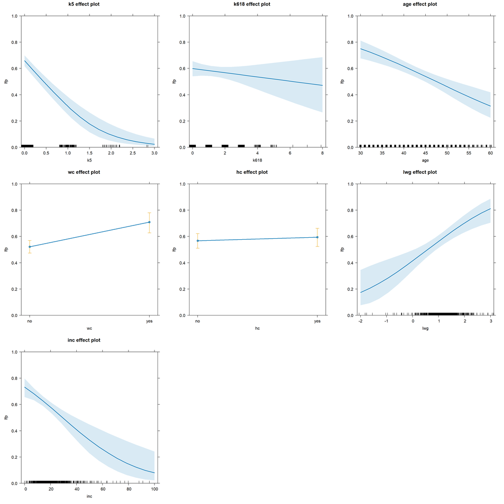

```r
## All effects plot: each variable's effect on Pr(lfp="yes") with others at average
## Adapted from SchoolClosing.r lines 84-88
library(effects)
plot(allEffects(GLM.lfp), type="response", ylim=c(0,1), ask=FALSE)
```

The all effects plot presents the estimated probability of labor force participation (`lfp = yes`) for each predictor, while all other variables are held at their mean values (or reference category for factors). The shaded areas represent 95% confidence bands.

- **`k5`:** The plot shows a steep and clear negative relationship. At the average values of all other variables, a wife with no young children has an estimated participation probability of approximately 0.65, which drops sharply to near zero when she has three young children. The confidence band widens at higher values of `k5`, reflecting the limited number of observations in that range.
- **`k618`:** The curve is nearly flat, declining only slightly from approximately 0.60 to 0.50 across the observed range. The very wide confidence band at higher values of `k618` indicates substantial uncertainty, which is consistent with the non-significant coefficient found in Task 2. The effect of older children on labor force participation is negligible.
- **`age`:** A clear and steady negative slope is visible, with participation probability declining from approximately 0.75 at age 30 to around 0.30 at age 60. The relatively narrow confidence band throughout suggests that this effect is estimated with good precision.
- **`wc`:** Wives who attended college (`wc = yes`) have a noticeably higher participation probability (approximately 0.71) compared to those who did not (`wc = no`, approximately 0.51). The confidence intervals for the two categories do not overlap substantially, confirming this is a meaningful difference.
- **`hc`:** The plot shows almost no visible difference between husbands who attended college and those who did not — both categories yield an estimated probability of approximately 0.58–0.60. The overlapping confidence intervals further confirm that husband’s education has no statistically distinguishable effect on the wife’s labor force participation in this model.
- **`lwg`:** The plot displays a clear positive S-shaped logistic curve. At the lower end of the observed log-wage range (around −2), the estimated participation probability is below 0.20, rising steeply to above 0.80 at higher wage values (around 3). The wide confidence band at the extremes reflects sparse data in those regions.
- **`inc`:** A pronounced negative curve is visible, with participation probability starting at approximately 0.72 when family income is near zero and declining rapidly to below 0.10 at an income level of around 100. This confirms that higher household income substantially reduces the wife’s financial need to work.

Overall, the all effects plots are consistent with the regression coefficients discussed in Task 2b. The variables `k5`, `age`, `lwg`, and `inc` show the most pronounced effects on the probability of labor force participation, while `k618` and `hc` exhibit virtually no visible effect.

## Task 3: Perform a likelihood ratio test [0.5 point]

Refine the model from task 2 by dropping all variables which you deem to be *not relevant*. Test whether these variables jointly have explanatory power or not. Properly state the null and the alternative hypotheses.

*Show your answer here.*

### 3 answer

Based on the results from Task 2, the variables `k618` and `hc` are both statistically non-significant at the conventional 5% level (p = 0.342 and p = 0.588, respectively), and their all-effects plots show virtually no meaningful influence on the participation probability. We therefore drop both variables to obtain a refined model.

The likelihood ratio test evaluates whether the two dropped variables jointly contribute explanatory power. The hypotheses are:

- **H₀:** $\beta_{k618} = \beta_{hc} = 0$ — the variables `k618` and `hc` jointly have no explanatory power beyond the remaining predictors.
- **H₁:** At least one of $\beta_{k618}$, $\beta_{hc}$ $\neq 0$ — at least one of the two dropped variables has explanatory power.

The LRT statistic is $\Lambda = -2(\ell_R - \ell_F)$, which follows a $\chi^2$ distribution with 2 degrees of freedom under H₀ (one degree of freedom per dropped variable).

**Full model (`GLM.lfp`):**

$$\log\left(\frac{\Pr(\text{lfp}_i = \text{yes})}{1 - \Pr(\text{lfp}_i = \text{yes})}\right) =
\beta_0 + \beta_1\, k5_i + \beta_2\, k618_i + \beta_3\, age_i
+ \beta_4\, wc^{yes}_i + \beta_5\, hc^{yes}_i + \beta_6\, lwg_i + \beta_7\, inc_i$$

**Restricted model (`GLM.lfp.r`) — drop `k618` and `hc`:**

$$\log\left(\frac{\Pr(\text{lfp}_i = \text{yes})}{1 - \Pr(\text{lfp}_i = \text{yes})}\right) =
\beta_0 + \beta_1\, k5_i + \beta_2\, age_i + \beta_3\, wc^{yes}_i
+ \beta_4\, lwg_i + \beta_5\, inc_i$$

```r
## Restricted model dropping k618 and hc (both non-significant in Task 2)
## Adapted from SchoolClosing.r lines 70-79 (GLM.03 restricted model + LRT pattern)
GLM.lfp.r <- glm(lfp ~ k5 + age + wc + lwg + inc,
                 family=binomial(logit), data=Mroz,
                 control=list(epsilon=1e-15, maxit=50, trace=FALSE))
summary(GLM.lfp.r, correlation=TRUE)
```

```
Call:
glm(formula = lfp ~ k5 + age + wc + lwg + inc, family = binomial(logit),
    data = Mroz, control = list(epsilon = 1e-15, maxit = 50,
        trace = FALSE))

Coefficients:
             Estimate Std. Error z value Pr(>|z|)
(Intercept)  2.901926   0.542915   5.345 9.04e-08 ***
k5          -1.431804   0.193209  -7.411 1.26e-13 ***
age         -0.058532   0.011416  -5.127 2.94e-07 ***
wcyes        0.872373   0.206397   4.227 2.37e-05 ***
lwg          0.615684   0.150147   4.101 4.12e-05 ***
inc         -0.033675   0.007801  -4.317 1.58e-05 ***
---
Signif. codes:  0 '***' 0.001 '**' 0.01 '*' 0.05 '.' 0.1 ' ' 1

(Dispersion parameter for binomial family taken to be 1)

    Null deviance: 1029.75  on 752  degrees of freedom
Residual deviance:  906.46  on 747  degrees of freedom
AIC: 918.46

Number of Fisher Scoring iterations: 4

Correlation of Coefficients:
      (Intercept) k5    age   wcyes lwg
k5    -0.51
age   -0.92        0.48
wcyes  0.09       -0.16 -0.02
lwg   -0.18       -0.04 -0.07 -0.22
inc   -0.21        0.07 -0.03 -0.30 -0.08
```

```r
logLik(GLM.lfp.r)
```

```
'log Lik.' -453.2277 (df=6)
```

```r
## Likelihood Ratio Test: restricted vs. full model
## H0: beta_k618 = beta_hc = 0  (k618 and hc jointly have no explanatory power)
## H1: at least one of beta_k618, beta_hc != 0
anova(GLM.lfp.r, GLM.lfp, test="LRT")
```

```
Analysis of Deviance Table

Model 1: lfp ~ k5 + age + wc + lwg + inc
Model 2: lfp ~ k5 + k618 + age + wc + hc + lwg + inc
  Resid. Df Resid. Dev Df Deviance Pr(>Chi)
1       747     906.46
2       745     905.27  2   1.1895   0.5517
```

The LRT statistic is $\Lambda =$ 1.1895 on 2 degrees of freedom, with a p-value of 0.5517.Since p = 0.5517 $\gg$ 0.05, we **fail to reject H₀**. The variables `k618` and `hc` jointly provide no statistically significant additional explanatory power over the restricted model. We therefore proceed with the refined model containing only `k5`, `age`, `wc`, `lwg`, and `inc`.

## Task 4: Conditional effects plots [1.5 points]

Generate conditional effects plots based on the refined model for the probability of the wife’s labor force participation for the income variable `inc`. Interpret the plots.

Assume two scenarios with the following value levels of the additional independent variables in the logistic regression model:

| Variable | Low Probability | High Probability |
| --- | --- | --- |
| k5 | 2 | 0 |
| age | 49 | 36 |
| wc | ‘no’ | ‘yes’ |
| lwg | 0.81 | 1.40 |

Discuss your plots for these two scenarios.

*Show your answer here.*

### 4 answer

Based on the refined model (`GLM.lfp.r`), we generate conditional effects plots for `inc` under two distinct wife profiles — one associated with low probability and one with high probability of labor force participation. All other variables are fixed at the scenario-specific values listed in the table above.

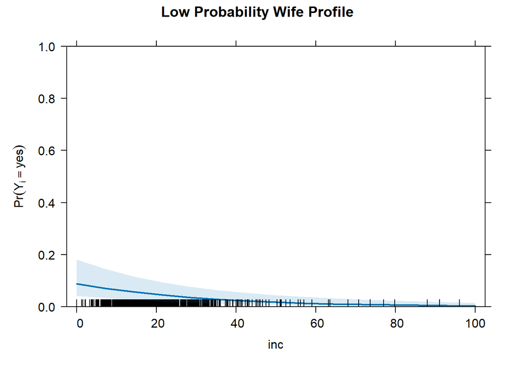

```r
## Conditional effects plots for inc under two scenarios
library(effects)

## Low probability wife profile: k5=2, age=49, wc='no', lwg=0.81
eff.lfp.low <- effect("inc", GLM.lfp.r,
                      given.values=c(k5=2, age=49, "wcyes"=0, lwg=0.81))
plot(eff.lfp.low, type="response", ylim=c(0,1),
     ylab=expression(Pr(Y[i]=="yes")),
     main="Low Probability Wife Profile")
```

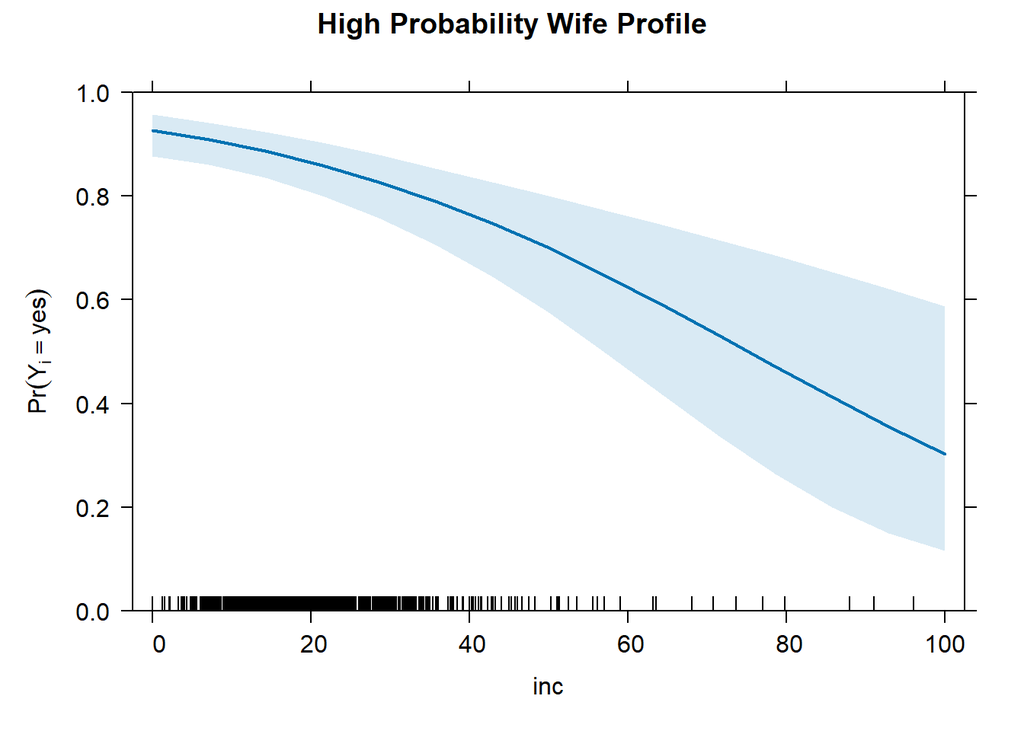

```r
## High probability wife profile: k5=0, age=36, wc='yes', lwg=1.40
eff.lfp.high <- effect("inc", GLM.lfp.r,
                       given.values=c(k5=0, age=36, "wcyes"=1, lwg=1.40))
plot(eff.lfp.high, type="response", ylim=c(0,1),
     ylab=expression(Pr(Y[i]=="yes")),
     main="High Probability Wife Profile")
```

The two plots illustrate how the same income variable `inc` operates very differently depending on the wife’s background characteristics.

- **Low Probability Wife Profile** (`k5=2`, `age=49`, `wc='no'`, `lwg=0.81`):The estimated participation probability starts at approximately 0.09 when family income is near zero, and declines steadily toward nearly zero as income approaches 100. The entire curve is compressed in the very low probability range (below 0.20), meaning that this wife profile is already strongly deterred from labor force participation by the combination of two young children, older age, and no college education. The relatively wide confidence band at low income values reflects uncertainty in that region, but the overall message is clear: regardless of income level, a wife with this profile has very little probability of participating in the labor force.
- **High Probability Wife Profile** (`k5=0`, `age=36`, `wc='yes'`, `lwg=1.40`):In sharp contrast, this profile begins at a very high participation probability of approximately 0.92 when family income is near zero. As income increases, the probability declines substantially in a smooth negative curve, reaching approximately 0.31 at an income level of 100. This plot reveals that income plays a much more visible and practically meaningful role for this type of wife — the negative effect of rising household income translates into a large, observable drop in participation probability across the income range.

**Comparing the two scenarios:** The key takeaway from this comparison is that the effect of `inc` on participation probability is not uniform — it depends heavily on where the baseline probability lies. For the low-probability profile, the curve is effectively floored near zero and income cannot push it much lower. For the high-probability profile, the logistic curve has ample room to descend, making the income effect far more visible.

# Part 2: Logistic Regression for Rates [2 points]

Continue using the `TexMix` package to analyse with logistic regression analysis of the percentage of the population below the poverty threshold in the census tracts of Dallas County.

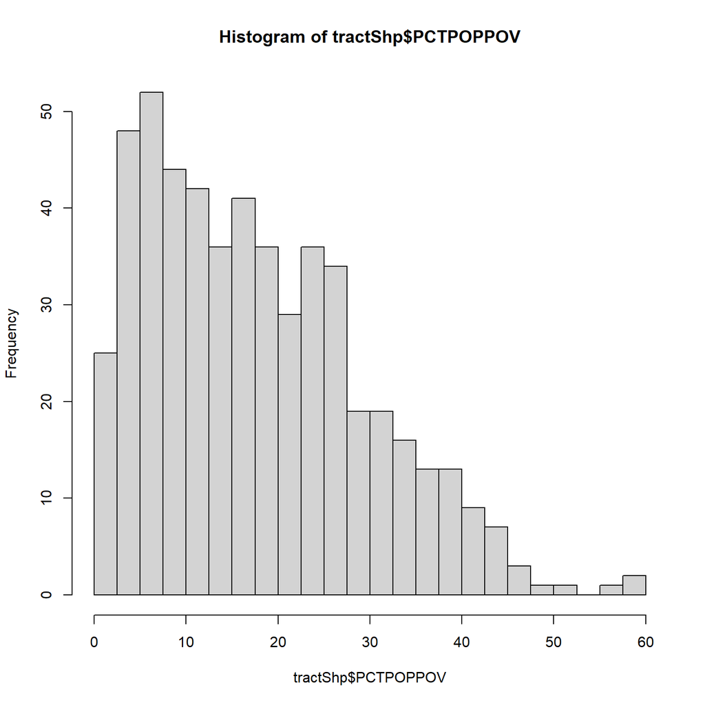

```r
library(TexMix); library(sp); library(car); library(effects)
data(tractShp)
tractShp <- tractShp[tractShp$NIGHTPOP!=0, ]   # Remove 2 airport tracts with NA's

hist(tractShp$PCTPOPPOV, breaks=seq(0, 60, by=2.5))
```

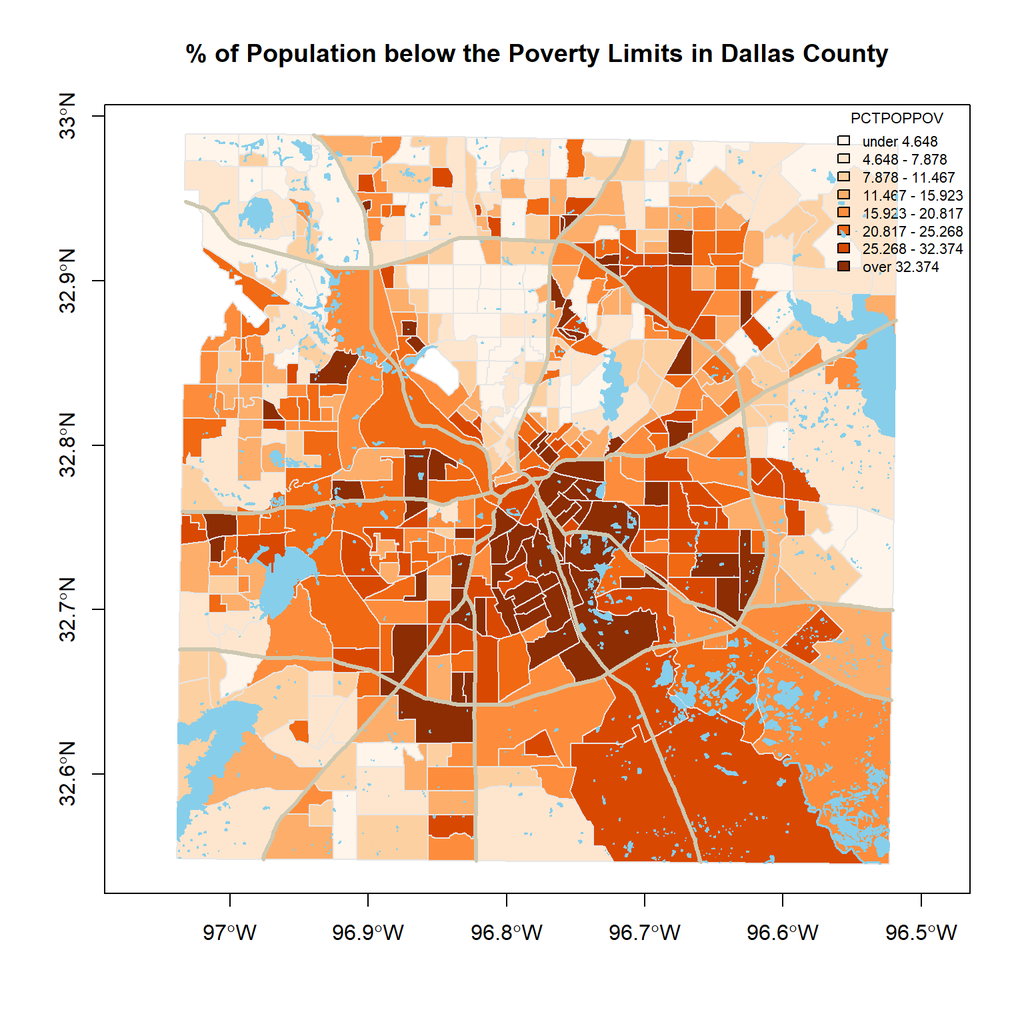

```r
mapColorRamp(tractShp$PCTPOPPOV, tractShp, breaks=8, legend.pos = "topright",
             legend.cex=0.7,
             map.title="% of Population below the Poverty Limits in Dallas County",
             legend.title="PCTPOPPOV")
sp::plot(lakesShp, col="skyblue", border="skyblue",add=T)
sp::plot(hwyShp, col="cornsilk3", lwd=3, add=T)
```

## Task 5: Before you can run a logistic regression analysis on the variable PCTPOPPOV you need to consider two issues. [0.5 points]

[a] The measurement units of `PCTPOPPOV` do not match the expected range of probabilities $0≤\Pr(PCTPOPPOV_i)≤1$. Look the definition of this variable up in the online help. Perform a proper scaling of the variable `PCTPOPPOV`. Justify your selected transformation.

*Show your answer here.*

### 5-a answer

The variable `PCTPOPPOV` is measured in percentage units (range approximately 0–60%), which does not satisfy the required probability range $0 \leq \Pr(\text{PCTPOPPOV}_i) \leq 1$ for logistic regression. Therefore, the variable is divided by 100 to convert it into a proportion.

```r
## Scale PCTPOPPOV from percentage (0-100) to proportion (0-1)
## Reference: GlasgowCode.R line 13 — gw$RATE2010 <- gw$OBSRES2010/gw$POP2001
tractShp$propPOPPOV <- tractShp$PCTPOPPOV / 100

## Verify the range is now within [0, 1]
range(tractShp$propPOPPOV, na.rm=TRUE)
```

```
[1] 0.0000000 0.5869875
```

[b] The variable `PCTPOPPOV` has an underlying denominator which needs to be used in `glm( )` function to account for the population at risk in each census tract. Justify your choice of the underlying denominator and weights variable?

*Show your answer here.*

### 5-b answer

The variable `PCTPOPPOV` is computed as the count of persons below the poverty threshold divided by the total nighttime population (`NIGHTPOP`) of each census tract. Therefore, `NIGHTPOP` serves as the underlying denominator (population at risk). Since census tracts vary considerably in population size, a tract with a large `NIGHTPOP` provides a more statistically reliable rate estimate than a small-population tract with the same observed proportion. Passing `weights = NIGHTPOP` in `glm()` allows the binomial model to correctly scale the variance of each observation as $\pi_i(1-\pi_i)/N_i$, giving larger tracts appropriately more influence in the estimation.

## Task 6: Weighted logistic model [0.5 points]

Run a logistic regression model of the transformed `PCTPOPPOV` with a proper weights setting using the set of 4 independent variables `PCTUNEMP+PCTPUB2WRK+PCTASIAN+PCTUNIVDEG`.

*Show your answer here.*

### 6 answer

```r
## Weighted logistic regression model for poverty rate
glm.pov <- glm(propPOPPOV ~ PCTUNEMP + PCTPUB2WRK + PCTASIAN + PCTUNIVDEG,
               weights = NIGHTPOP,
               data = tractShp,
               family = binomial)
summary(glm.pov)
```

```
Call:
glm(formula = propPOPPOV ~ PCTUNEMP + PCTPUB2WRK + PCTASIAN +
    PCTUNIVDEG, family = binomial, data = tractShp, weights = NIGHTPOP)

Coefficients:
              Estimate Std. Error z value Pr(>|z|)
(Intercept) -1.3652686  0.0050156 -272.21   <2e-16 ***
PCTUNEMP     0.0283250  0.0005068   55.89   <2e-16 ***
PCTPUB2WRK   0.0686421  0.0004461  153.87   <2e-16 ***
PCTASIAN    -0.0046790  0.0002686  -17.42   <2e-16 ***
PCTUNIVDEG  -0.0233273  0.0001175 -198.54   <2e-16 ***
---
Signif. codes:  0 '***' 0.001 '**' 0.01 '*' 0.05 '.' 0.1 ' ' 1

(Dispersion parameter for binomial family taken to be 1)

    Null deviance: 234085  on 526  degrees of freedom
Residual deviance:  94974  on 522  degrees of freedom
AIC: 99202

Number of Fisher Scoring iterations: 4
```

```r
## Account for over-dispersion (GlasgowCode.R line 22)
glm.pov.qb <- update(glm.pov, family=quasibinomial)
summary(glm.pov.qb)
```

```
Call:
glm(formula = propPOPPOV ~ PCTUNEMP + PCTPUB2WRK + PCTASIAN +
    PCTUNIVDEG, family = quasibinomial, data = tractShp, weights = NIGHTPOP)

Coefficients:
             Estimate Std. Error t value Pr(>|t|)
(Intercept) -1.365269   0.067981 -20.083  < 2e-16 ***
PCTUNEMP     0.028325   0.006869   4.124 4.34e-05 ***
PCTPUB2WRK   0.068642   0.006047  11.352  < 2e-16 ***
PCTASIAN    -0.004679   0.003640  -1.285    0.199
PCTUNIVDEG  -0.023327   0.001593 -14.648  < 2e-16 ***
---
Signif. codes:  0 '***' 0.001 '**' 0.01 '*' 0.05 '.' 0.1 ' ' 1

(Dispersion parameter for quasibinomial family taken to be 183.711)

    Null deviance: 234085  on 526  degrees of freedom
Residual deviance:  94974  on 522  degrees of freedom
AIC: NA

Number of Fisher Scoring iterations: 4
```

A weighted binomial logistic regression model was fitted using `glm()` with `family=binomial`, where `propPOPPOV` (the proportion of population below the poverty threshold) serves as the dependent variable and `NIGHTPOP` is passed to the `weights` argument to account for the differing population sizes across census tracts.

However, the ratio of the residual deviance to its degrees of freedom (94974 / 522 = 181.9) far exceeds 1, indicating severe over-dispersion — the observed variation in poverty proportions is much larger than what the binomial distribution assumes. As demonstrated in `GlasgowCode.R`, a quasi-binomial model is therefore fitted using `update(glm.pov, family=quasibinomial)` to obtain correctly inflated standard errors. The estimated dispersion parameter is $\hat{\phi} =$ 183.7, confirming that the binomial standard errors were underestimated by a factor of approximately $\sqrt{\hat{\phi}} \approx$ 13.6.

Under the quasi-binomial model, three of the four predictors remain statistically significant. The unemployment rate (`PCTUNEMP`, $\hat{b} =$ 0.0283, $p$ < 0.001) and the public transit commuting rate (`PCTPUB2WRK`, $\hat{b} =$ 0.0686, $p$ < 0.001) remain positively and significantly associated with poverty rates on the log-odds scale, indicating that tracts with higher unemployment or greater reliance on public transit tend to have higher poverty proportions. The percentage of university degree holders (`PCTUNIVDEG`, $\hat{b} =$ -0.0233, $p$ < 0.001) remains strongly and negatively associated with poverty rates. In contrast, the percentage of Asian residents (`PCTASIAN`, $\hat{b} =$ -0.0047, $p =$ 0.199) loses statistical significance once over-dispersion is properly accounted for, suggesting that its apparent effect in the binomial model was an artifact of underestimated standard errors rather than a genuine association. The model reduces the null deviance from 234,085 to a residual deviance of 94,974 on 522 degrees of freedom, indicating that the three significant predictors together explain a meaningful portion of the variation in poverty rates across Dallas County census tracts.

## Task 7: Interpretation [1 points]

Interpret the model by using default conditional effects plots for the 4 independent variables.

*Show your answer here.*

### 7 answer

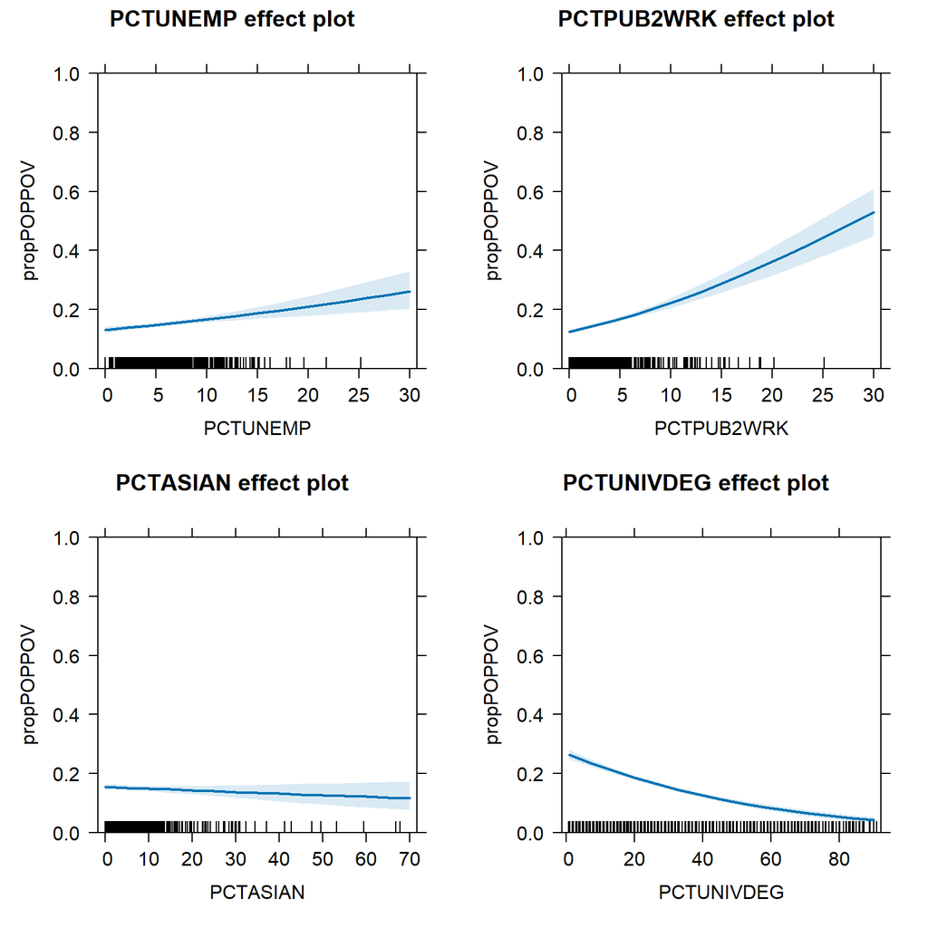

```r
## Default conditional effects plots for all 4 independent variables
## Using quasi-binomial model to correctly reflect over-dispersion
plot(allEffects(glm.pov.qb), type="response", ylim=c(0,1), ask=FALSE)
```

The conditional effects plots display the predicted poverty proportion (`propPOPPOV`) for each independent variable while holding the remaining three variables at their respective mean values. All curves are shown on the probability scale (0 to 1) as specified by `type="response"`. The plots are based on the quasi-binomial model (`glm.pov.qb`), which correctly accounts for the severe over-dispersion ($\hat{\phi} \approx$ 183.7) identified in Task 6. Compared to the binomial model, the confidence bands are noticeably wider, reflecting the true uncertainty in the estimates after adjusting for over-dispersion.

- **PCTUNEMP** shows a moderate positive association with the poverty proportion. As the unemployment rate increases from 0% to 30%, the predicted poverty proportion rises gradually from approximately 0.131 to 0.261. The curve is relatively gentle, reflecting the comparatively smaller coefficient of this variable.
- **PCTPUB2WRK** shows the strongest positive association among the four predictors. The predicted poverty proportion increases steeply and non-linearly from approximately 0.126 at low values to 0.53 at the upper end of the observed range, indicating that census tracts where a large share of workers rely on public transit tend to have substantially higher poverty rates. This is consistent with public transit dependence being a marker of limited automobile access and lower household income.
- **PCTASIAN** shows a nearly flat curve across its observed range, with the predicted poverty proportion declining only marginally from approximately 0.156 to 0.117. This is consistent with the quasi-binomial results in Task 6, where `PCTASIAN` loses statistical significance ($p =$ 0.199) once over-dispersion is properly accounted for. The apparent significance in the binomial model was an artifact of underestimated standard errors.
- **PCTUNIVDEG** shows a strong negative association. The predicted poverty proportion drops sharply from approximately 0.264 when the university degree holder percentage is near zero, declining steeply and leveling off toward 0.043 as educational attainment increases. This reflects the well-established relationship between higher education and lower poverty risk, as higher levels of education are associated with better employment opportunities and higher earning potential.

Overall, the plots confirm that unemployment (`PCTUNEMP`) and public transit usage (`PCTPUB2WRK`) are significant positive predictors of poverty, while education (`PCTUNIVDEG`) is the most influential negative predictor. The variable `PCTASIAN`, whose effect appeared significant under the binomial assumption, is not a reliable predictor once over-dispersion is properly accounted for. Among the three significant variables, `PCTUNIVDEG` appears to have the largest practical impact on reducing poverty rates across Dallas County census tracts.